# Part II - Video Game Sales Data

## by Diego França

## Investigation Overview

> On this project, a insights to better present and see the results, on few steps it was used a filter on the dataset to see only the outliers what made the visualizations much more clear and with a high dark int ratio. Other point, was to compare the results as it was evoluating to the initial result, what has shown to have different results depend of the perpective.

## Dataset Overview

> A dataset about video games sales extract from kaggle with more than 16500 games. The dataset have collumns with name, platform, year, genre, publisher, north america sale, europe sales, japan sales, other region sales and global sales, all sales information are in milions dollars scale.

## Step 1

> Which genre are the most popular all data set? Should the most popular be the best seller?

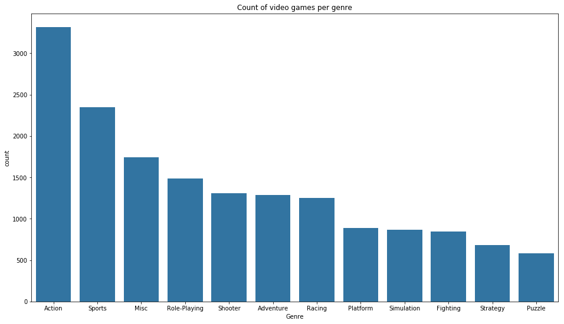

## Step 2

> As we saw, Action is the most popular video game genre. Now that we know that, let's add Global Sales variable to find out which one are the best seller and if it is action or not.

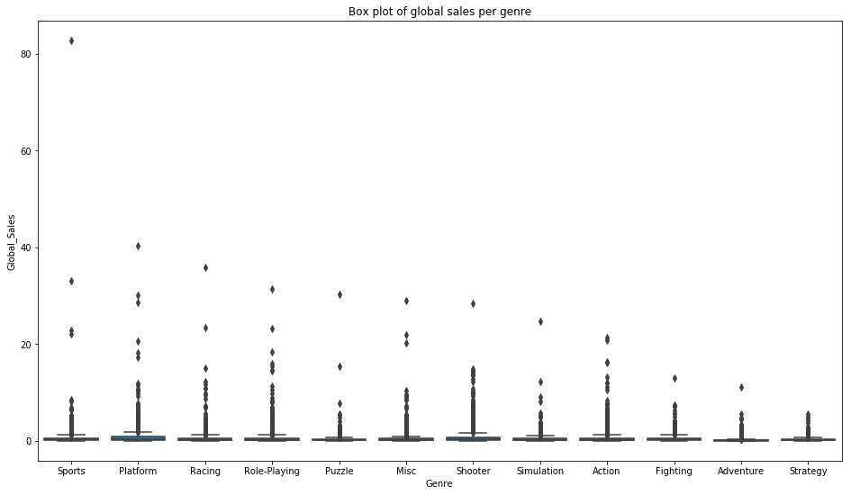

## Step 3

> Alright, it looked that action got down to the 9th position loosing to sports on a global scale. Now, let's plot adding publisher variable to see which one is the best selles as well and to go a litlle depper, let's break in a region wise? Is it different than before? To better visualizarion, let's plot only the Global sales greather than 10 milion.

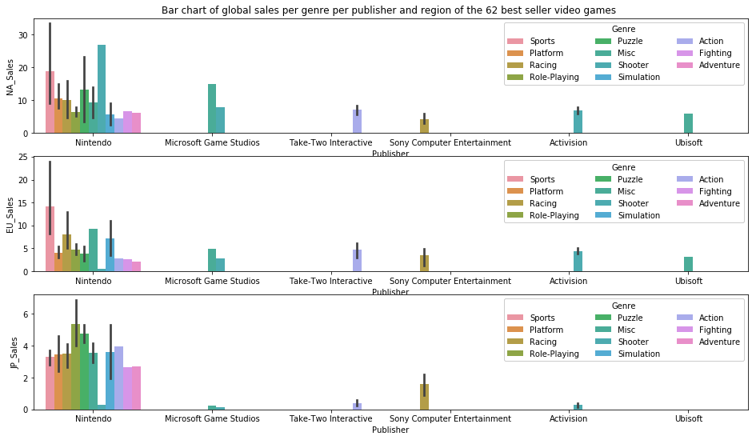